# Analýza časových radov projekt

Matúš Varhaník

18.2.2021

# Načítanie časového radu a základný popis

načítanie knižníc

```r
library(readxl)
library(prettydoc)
library(magrittr)
#library(knitr)
#library(dplyr)
#library(date)
#library(lubridate)
library(randtests)
#library(car)
#library(dynlm)
#library(forecast)
#library(aTSA)
`%>%` <- magrittr::`%>%`  # pipe operator
```

Načítanie dát, pričom dáta sa preškálujú, aby sa pracovalo s menšími hodnotami

```r
D <- read_excel("E:/Semester6/casove_rady/download.xlsx")
D$emp<-D$emp/1000
```

### Popis časového radu

časový rad popisuje vývoj počtu zamestnancov vo Švajčiarsku  
v rokoch 1991-2020 za kvartálne obdobia

### Graf a základné vlastnosti

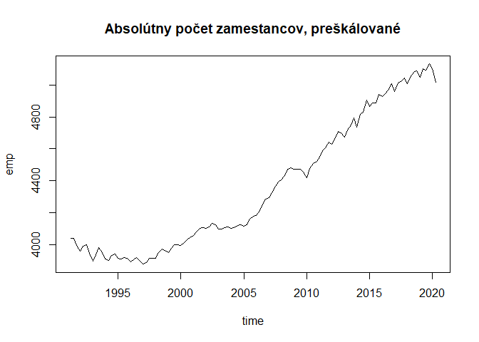

```r
plot(D$time,D$emp,xlab="time", ylab="emp",
     type="l", main="Absolútny počet zamestancov, preškálované")
```

```r
rbind(maximum = max(D$emp),minimum=min(D$emp),priemer=mean(D$emp),
      med=median(D$emp),odchylka=sd(D$emp) )
```

```
##               [,1]
## maximum  5130.0231
## minimum  3878.4400
## priemer  4356.9938
## med      4176.3121
## odchylka  409.3759
```

# Dekompozícia časového radu: trend

rozdelenie na trénovaciu a vyhodnocovaciu zložku

```r
dat <-split(D,D$time>= as.POSIXct("2014-04-01"))%>% setNames(c("train","eval"))
```

vykreslenie rozdeleného časového radu

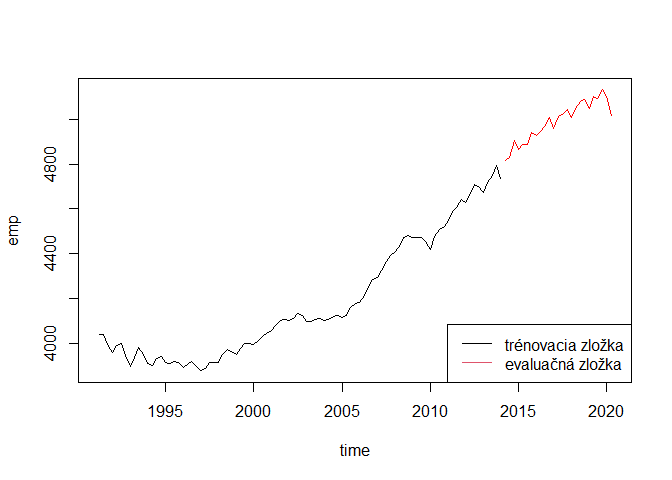

```r
plot(emp ~ time, do.call(rbind, dat), type="n")
lines(emp ~ time, dat$train)
lines(emp ~ time, dat$eval, col="red")
legend("bottomright", legend=c("trénovacia zložka", "evaluačná zložka"),
       lty=1, col=c(1,2))
```

list pre modely

```r
model <- list()
```

formátovanie času na roky

```r
dat$train$year <- format(as.Date(dat$train$time, format="%Y-%m-%d"),"%Y")
dat$train <- dplyr::mutate(dat$train,year = lubridate::decimal_date(time),
                           quart= lubridate::quarter(time),
                           quart = factor(quart, ordered=F))
dat$train$year <- as.vector(dat$train$year)

dat$eval$year <- format(as.Date(dat$eval$time, format="%Y-%m-%d"),"%Y")
dat$eval <- dplyr::mutate(dat$eval,year = lubridate::decimal_date(time),
                          quart= lubridate::quarter(time),
                          quart = factor(quart, ordered=F))
dat$eval$year <- as.vector(dat$eval$year)
```

## lineárny trend

vytvorenie trendu

```r
model$Tlin <- lm(emp ~ year, dat$train)
```

uloženie premenných

```r
dat$train$Tlin <- model$Tlin$fitted.values
```

sumárna štatistika a intervaly spoľahlivosti

```r
summary(model$Tlin)
```

```
##
## Call:
## lm(formula = emp ~ year, data = dat$train)
##
## Residuals:
##     Min      1Q  Median      3Q     Max
## -158.50  -79.76  -35.92   69.36  278.53
##
## Coefficients:
##               Estimate Std. Error t value Pr(>|t|)
## (Intercept) -70045.325   3275.059  -21.39   <2e-16 ***
## year            37.067      1.635   22.67   <2e-16 ***
## ---
## Signif. codes:  0 '***' 0.001 '**' 0.01 '*' 0.05 '.' 0.1 ' ' 1
##
## Residual standard error: 104.1 on 90 degrees of freedom
## Multiple R-squared:  0.8509, Adjusted R-squared:  0.8493
## F-statistic: 513.7 on 1 and 90 DF,  p-value: < 2.2e-16
```

```r
confint(model$Tlin)
```

```
##                    2.5 %       97.5 %
## (Intercept) -76551.80071 -63538.84976
## year            33.81772     40.31564
```

## po častiach lineárny trend

výber uzlových hodnôt

```r
knots <- dat$train$year[c(24,55)]
dat$train$dummy1 <- pmax(dat$train$year - knots[1], 0)
dat$train$dummy2 <- pmax(dat$train$year - knots[2], 0)
#vytvorenie modelu
model$TpwlC <- lm(emp ~ year + dummy1 + dummy2, dat$train,x=T)
```

uloženie premenných

```r
dat$train$TpwlC <- model$TpwlC$fitted.values
# sumárna štatistika a intervaly spoľahlivosti
summary(model$TpwlC)
```

```
##
## Call:
## lm(formula = emp ~ year + dummy1 + dummy2, data = dat$train,
##     x = T)
##
## Residuals:
##     Min      1Q  Median      3Q     Max
## -84.829 -22.835  -0.441  22.046  70.026
##
## Coefficients:
##              Estimate Std. Error t value Pr(>|t|)
## (Intercept) 34691.351   5736.067   6.048 3.48e-08 ***
## year          -15.418      2.875  -5.362 6.56e-07 ***
## dummy1         47.553      4.084  11.644  < 2e-16 ***
## dummy2         34.874      2.856  12.211  < 2e-16 ***
## ---
## Signif. codes:  0 '***' 0.001 '**' 0.01 '*' 0.05 '.' 0.1 ' ' 1
##
## Residual standard error: 32 on 88 degrees of freedom
## Multiple R-squared:  0.9862, Adjusted R-squared:  0.9858
## F-statistic:  2102 on 3 and 88 DF,  p-value: < 2.2e-16
```

```r
confint(model$TpwlC)
```

```
##                   2.5 %       97.5 %
## (Intercept) 23292.12383 46090.578511
## year          -21.13192    -9.703417
## dummy1         39.43727    55.669590
## dummy2         29.19809    40.549041
```

## kvadratický trend

vytvorenie trendu

```r
model$Tqua <- lm(emp ~ year + I(year^2), dat$train)
```

uloženie premenných

```r
dat$train$Tqua <- model$Tqua$fitted.values
```

sumárna štatistika a intervaly spoľahlivosti

```r
summary(model$Tqua)
```

```
##
## Call:
## lm(formula = emp ~ year + I(year^2), data = dat$train)
##
## Residuals:
##     Min      1Q  Median      3Q     Max
## -77.172 -29.757  -3.146  25.881  92.618
##
## Coefficients:
##               Estimate Std. Error t value Pr(>|t|)
## (Intercept)  9.622e+06  4.224e+05   22.78   <2e-16 ***
## year        -9.643e+03  4.218e+02  -22.86   <2e-16 ***
## I(year^2)    2.417e+00  1.053e-01   22.95   <2e-16 ***
## ---
## Signif. codes:  0 '***' 0.001 '**' 0.01 '*' 0.05 '.' 0.1 ' ' 1
##
## Residual standard error: 39.82 on 89 degrees of freedom
## Multiple R-squared:  0.9784, Adjusted R-squared:  0.978
## F-statistic:  2020 on 2 and 89 DF,  p-value: < 2.2e-16
```

```r
confint(model$Tqua)
```

```
##                     2.5 %        97.5 %
## (Intercept)  8.783073e+06  1.046158e+07
## year        -1.048088e+04 -8.804556e+03
## I(year^2)    2.207511e+00  2.626041e+00
```

## exponenciálny trend

vytvorenie trendu

```r
model$Texp <- lm(log(emp) ~ year, dat$train)
```

uloženie premenných

```r
dat$train$Texp <- exp(model$Texp$fitted.values)
```

sumárna štatistika a intervaly spoľahlivosti

```r
summary(model$Texp)
```

```
##
## Call:
## lm(formula = log(emp) ~ year, data = dat$train)
##
## Residuals:
##       Min        1Q    Median        3Q       Max
## -0.035690 -0.018972 -0.006761  0.017077  0.066257
##
## Coefficients:
##               Estimate Std. Error t value Pr(>|t|)
## (Intercept) -9.1050554  0.7460823  -12.20   <2e-16 ***
## year         0.0087098  0.0003726   23.38   <2e-16 ***
## ---
## Signif. codes:  0 '***' 0.001 '**' 0.01 '*' 0.05 '.' 0.1 ' ' 1
##
## Residual standard error: 0.02372 on 90 degrees of freedom
## Multiple R-squared:  0.8586, Adjusted R-squared:  0.857
## F-statistic: 546.6 on 1 and 90 DF,  p-value: < 2.2e-16
```

```r
confint(model$Texp)
```

```
##                     2.5 %       97.5 %
## (Intercept) -10.587278222 -7.622832623
## year          0.007969643  0.009449917
```

## spoločný graf pre všetky trendy na porovnanie

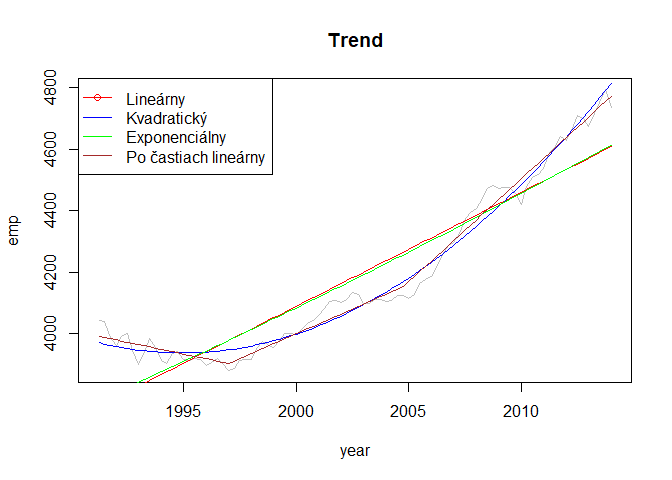

```r
with(dat$train, {
  plot(emp ~ year, main="Trend",type="l", col="grey")
  lines(year, Tlin, col="red")
  lines(year, Tqua, col="blue")
  lines(year, Texp, col="green")
  lines(year, TpwlC, col="brown")
  legend("topleft", legend=c("Lineárny", "Kvadratický", "Exponenciálny",
   "Po častiach lineárny"), pch=c(1,NA,NA,NA,NA), col=c("red","blue","green","brown"),
  lty=c(1,1,1,1))
}
)
```

## Výber vhodného trendu

Najvhodnejším trendom pre náš model bude po častiach lineárny trend. Z grafu prichádzal do úvahy aj kvadratický trend, ale zvolil som po častiach lineárny na základe koeficientu determinácie.

uloženie a vykreslenie reziduí

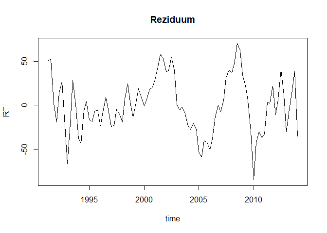

```r
dat$train$RT <- model$TpwlC$residuals
plot(RT ~ time, dat$train, type="l", main="Reziduum")
```

# Dekompozícia časového radu: sezónna zložka

autokorelačná funkcia

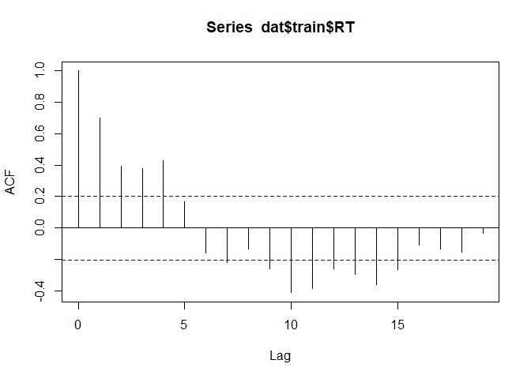

```r
acf(dat$train$RT)
```

na autokorelačnej funkcií nevidíme výraznú sezónnosť časového radu ## model sezónnej zložky pomocou goniometrických funkcií vytvorenie modelu

```r
model$Scos <- lm(RT ~
                   cos(2*pi*year/1) + sin(2*pi*year/1) +
                   cos(2*pi*year/1*2) + sin(2*pi*year/1*2)
                 ,dat$train)
```

sumárna štatistika modelu

```r
summary(model$Scos)
```

```
##
## Call:
## lm(formula = RT ~ cos(2 * pi * year/1) + sin(2 * pi * year/1) +
##     cos(2 * pi * year/1 * 2) + sin(2 * pi * year/1 * 2), data = dat$train)
##
## Residuals:
##     Min      1Q  Median      3Q     Max
## -67.111 -18.643  -1.411  15.376  56.754
##
## Coefficients:
##                          Estimate Std. Error t value Pr(>|t|)
## (Intercept)                0.2646     3.3990   0.078    0.938
## cos(2 * pi * year/1)     -14.3972    11.3273  -1.271    0.207
## sin(2 * pi * year/1)      -2.8085     5.1326  -0.547    0.586
## cos(2 * pi * year/1 * 2)  -3.5853    12.1988  -0.294    0.770
## sin(2 * pi * year/1 * 2) -70.4848   440.9531  -0.160    0.873
##
## Residual standard error: 29.84 on 87 degrees of freedom
## Multiple R-squared:  0.1405, Adjusted R-squared:  0.1009
## F-statistic: 3.554 on 4 and 87 DF,  p-value: 0.009825
```

uloženie odhadnutých parametrov

```r
dat$train$Scos <- model$Scos$fitted.values
```

graf sezónnej zložky pomocou goniometrických funkcií spolu s reziduami

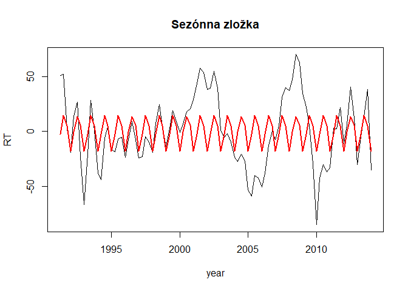

```r
plot(RT ~ year, dat$train, main="Sezónna zložka", type="l")
lines(Scos ~ year, dat$train, col="red", lwd=2)
```

## model sezónnej zložky pomocou dummy variables

príprava dummy variables

```r
dummyS <- as.data.frame(
  sapply(
    'names<-'(2:4, paste0("Q", 2:4)),
    function(x) (round(( dat$train$year-floor( dat$train$year))*4)+1) %in% x
  ) * 1
)
dat$train <- cbind( dat$train, dummyS)
```

vytvorenie modelu pomocou dummy variables

```r
model$Smkp <- lm(RT ~ Q2 + Q3 + Q4, dat$train)
```

sumárna štatistika modelu

```r
summary(model$Smkp)
```

```
##
## Call:
## lm(formula = RT ~ Q2 + Q3 + Q4, data = dat$train)
##
## Residuals:
##     Min      1Q  Median      3Q     Max
## -67.122 -18.964  -1.267  16.048  57.171
##
## Coefficients:
##             Estimate Std. Error t value Pr(>|t|)
## (Intercept)  -17.707      6.188  -2.862  0.00526 **
## Q2            15.940      8.750   1.822  0.07192 .
## Q3            32.026      8.750   3.660  0.00043 ***
## Q4            22.861      8.750   2.613  0.01057 *
## ---
## Signif. codes:  0 '***' 0.001 '**' 0.01 '*' 0.05 '.' 0.1 ' ' 1
##
## Residual standard error: 29.67 on 88 degrees of freedom
## Multiple R-squared:   0.14,  Adjusted R-squared:  0.1106
## F-statistic: 4.773 on 3 and 88 DF,  p-value: 0.003952
```

uloženie odhadnutých parametrov

```r
dat$train$Smkp <- model$Smkp$fitted.values
```

graf sezónnej zložky pomocou dummy variables spolu s reziduami

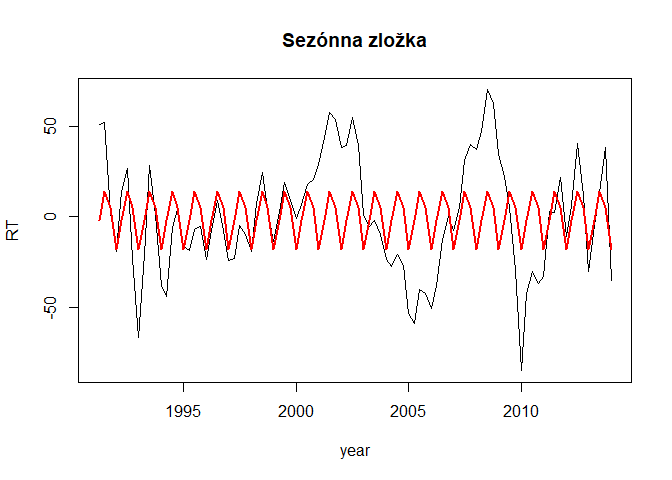

```r
plot(RT ~ year, dat$train, main="Sezónna zložka", type="l")
lines(Smkp ~ year, dat$train, col="red", lwd=2)
```

## výber vhodného modelu sezónnej zložky

Oba modely sezónnej zložky sú prakticky totožné, pre jednoduchosť teda vyberiem modelovanie pomocou dummy variables, nakoľko kvartálne dáta potrebujú len 3 kvalitatívne premenné.

uloženie a vykreslenie reziduí

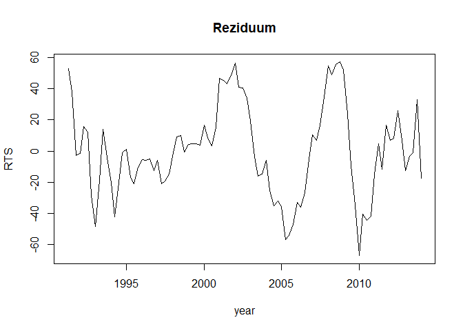

```r
dat$train$RTS <- model$Smkp$residuals
plot(RTS ~ year, dat$train, type="l", main="Reziduum")
```

vykreslenie dát spolu so sezónnou zložkou a a trendom. Vidíme, že sezónna zložka je podľa očakávania nevýrazná

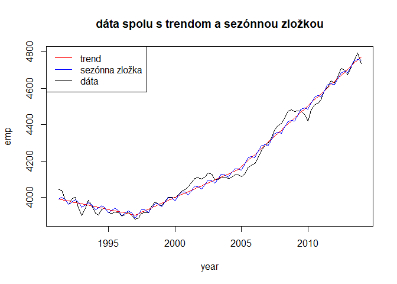

```r
plot(emp~year,dat$train, col="black",type="l",
     main="dáta spolu s trendom a sezónnou zložkou")
lines(TpwlC~year,dat$train,col="red")
lines(I(TpwlC+Smkp)~ year, dat$train,type="l", col="blue")
legend("topleft", legend=c("trend", "sezónna zložka","dáta"),
       col=c("red","blue","black"), lty=c(1,1,1))
```

# Dekompozícia časového radu: cyklická zložka

## diskrétna Fourierova transformácia, periodogram

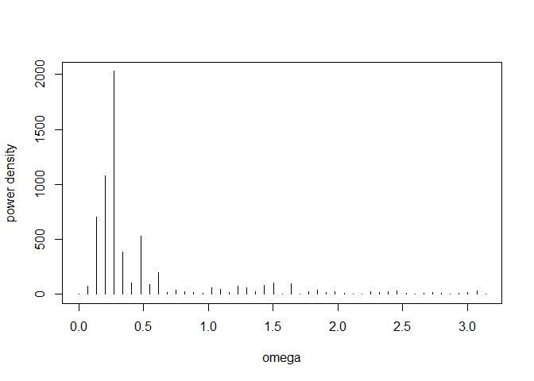

```r
dat.FFT <- dat$train$RTS %>%
  fft() %>%
  abs() %>% '^'(2) %>% '/'(2*pi*length(.)) %>%
  head(floor(length(.)/2+1))

omega <- 2*pi*seq(0, along.with = dat.FFT)/nrow(dat$train)
period <- 2*pi/omega
plot(omega, dat.FFT, ylab="power density", type="h")
```

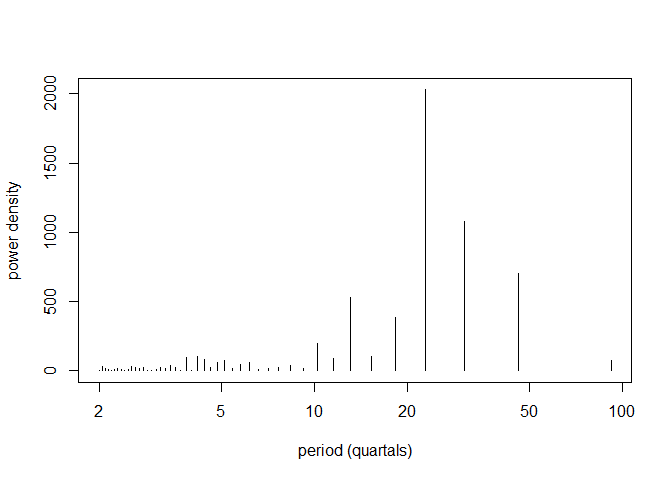

```r
plot(period, dat.FFT, ylab="power density", xlab="period (quartals)", type="h", log="x")
```

## Výber významných frekvencií

```r
spektrum <- data.frame(f = dat.FFT, omega=omega, period=period)
```

zoradenie od najväčšej po najmenšiu

```r
spektrum <- spektrum[order(spektrum$f, decreasing = TRUE), ]
```

test významnosti, ktorý odstráni bezvýznamné periódy

```r
vyznamne <- cbind(spektrum[0,],
                  data.frame(test.stat = numeric(0), crit.val = numeric(0)))
spek <- spektrum
repeat {
  test <- data.frame(test.stat = spek$f[1]/sum(spek$f),
                     crit.val = 1 - (0.05/nrow(spek))^(1/(nrow(spek)-1))
  )
  if(test$test.stat > test$crit.val) {
    vyznamne <- rbind(vyznamne, cbind(spek[1,],test));
    spek <- spek[-1,]
  } else break
}
rm(spek, test)
```

výpis významných periód

```r
vyznamne
```

```
##           f     omega   period test.stat  crit.val
## 5 2027.7632 0.2731820 23.00000 0.3288406 0.1382788
## 4 1075.8211 0.2048865 30.66667 0.2599456 0.1407134
## 3  700.1613 0.1365910 46.00000 0.2286004 0.1432421
## 8  530.1798 0.4780684 13.14286 0.2243998 0.1458706
## 6  385.5364 0.3414775 18.40000 0.2103909 0.1486052
```

našli sme viacero významných frekvencií, dalej ich spresníme pomocou spojitého výberového spektra # Spresnenie významných periód vytvorenie spojitej spektrálnej hustoty

```r
SpecDens <- Vectorize(
  FUN = function(omega, acov=NULL, data=NULL) {
    if(is.null(acov)) {
      if(is.null(data)) {
        stop("Please provide either vector of autocovariance function values or time series data.")
      }
      else acov <- acf(data, type="covariance", plot=FALSE)
    }
    k <- seq(to=length(acov)-1)
    ( acov[1] + 2*sum(acov[-1]*cos(k*omega)) ) / (2*pi)
  },
  vectorize.args = "omega"
)
```

spresnenie významných frekvencií

```r
dat.ACF <- as.numeric( acf(dat$train$RTS, lag.max=nrow(dat$train)/1.2,
                           type="covariance", plot=FALSE)$acf )
spresnene <- sapply(
  vyznamne$omega,
  function(x) optimize(SpecDens,
                       interval=x+c(1,-1)*pi/length(dat.FFT),
                       acov=dat.ACF,
                       maximum=T
  )$maximum
)
vyznamne <- cbind(vyznamne, data.frame(omega_sm=spresnene,
                                       period_sm=2*pi/spresnene
)
)
```

výpis spresnených významných hodnôt, odstránenie prebytočného poľa

```r
vyznamne
```

```
##           f     omega   period test.stat  crit.val  omega_sm period_sm
## 5 2027.7632 0.2731820 23.00000 0.3288406 0.1382788 0.2774125  22.64925
## 4 1075.8211 0.2048865 30.66667 0.2599456 0.1407134 0.1815989  34.59924
## 3  700.1613 0.1365910 46.00000 0.2286004 0.1432421 0.1816181  34.59559
## 8  530.1798 0.4780684 13.14286 0.2243998 0.1458706 0.4664090  13.47141
## 6  385.5364 0.3414775 18.40000 0.2103909 0.1486052 0.2774043  22.64992
```

```r
rm(spresnene)
```

```r
model$C <- lm(RTS ~ cos(2*pi*year/(22.6/4)) + sin(2*pi*year/(22.6/4))+
                cos(2*pi*year/(34.6/4)) + sin(2*pi*year/(34.6/4))+
                cos(2*pi*year/(13.5/4)) + sin(2*pi*year/(13.5/4)),
              dat$train,x=T
)

summary(model$C)$sigma
```

```
## [1] 17.65557
```

```r
dat$train$C <- model$C$fitted.values
```

vykreslenie cyklickej zložky spolu s reziduami

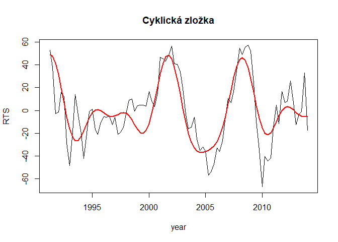

```r
plot(RTS ~ year, dat$train, main="Cyklická zložka",type="l")
lines(C ~ year, dat$train, col="red", lwd=2)
```

# Spoločný model pre všetky systematické zložky

```r
model$TSC <- lm(emp ~ year +TpwlC + # trend
                  Smkp + # sezónna zložka
                  C, # cyklická zložka,
                dat$train)
```

sumárna štatistika modelu

```r
summary(model$TSC)
```

```
##
## Call:
## lm(formula = emp ~ year + TpwlC + Smkp + C, data = dat$train)
##
## Residuals:
##    Min     1Q Median     3Q    Max
## -51.99 -10.12   0.02   9.77  47.82
##
## Coefficients:
##               Estimate Std. Error t value Pr(>|t|)
## (Intercept) -3.103e+03  1.389e+03  -2.235    0.028 *
## year         1.629e+00  7.287e-01   2.235    0.028 *
## TpwlC        9.622e-01  1.824e-02  52.760  < 2e-16 ***
## Smkp         9.717e-01  1.512e-01   6.429 6.68e-09 ***
## C            1.027e+00  7.612e-02  13.496  < 2e-16 ***
## ---
## Signif. codes:  0 '***' 0.001 '**' 0.01 '*' 0.05 '.' 0.1 ' ' 1
##
## Residual standard error: 16.97 on 87 degrees of freedom
## Multiple R-squared:  0.9962, Adjusted R-squared:  0.996
## F-statistic:  5664 on 4 and 87 DF,  p-value: < 2.2e-16
```

koeficient determinácie naznačuje, že model dobre zachytáva časový rad uloženie celkového modelu a vykreslenie zostávajúcich reziduí

```r
dat$train$TSC <- model$TSC$fitted.values
dat$train$RTSC <- model$TSC$residuals
```

vykreslenie spoločného modelu spolu s pôvodnými dátami

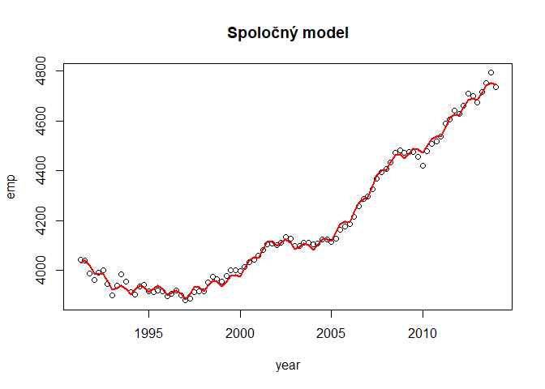

```r
plot(emp ~ year, dat$train, main="Spoločný model")
lines(TSC ~ year, dat$train, col="red", lwd=2)
```

# Testy náhodnosti reziduí

vykreslenie zostávajúcich reziduí

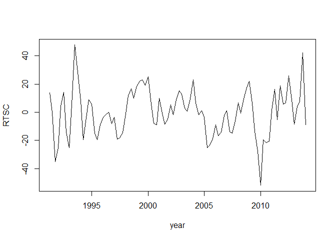

```r
plot(RTSC ~ year, dat$train, main="", type="l")
```

```r
car::durbinWatsonTest(model$TSC)
```

```
##  lag Autocorrelation D-W Statistic p-value
##    1       0.5448064     0.8996483       0
##  Alternative hypothesis: rho != 0
```

test naznačuje prítomnosť autokolerácie

## Test nulovosti autokorelácií

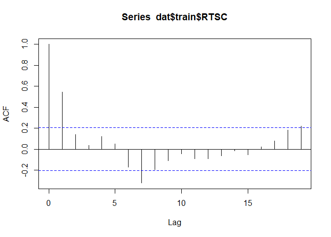

```
## [1]  1  7 19
```

```r
which(abs(acf(dat$train$RTSC)$acf[-1]) > 2/sqrt(length(dat$train$RTSC)))
```

vyzera to, že v reziduálnej zložke sa stále nachádzajú významné kolerácie, najviac pre posunutie 1 ale aj iné posunutia

## Znamienkový test

```r
randtests::difference.sign.test(dat$train$RTSC)
```

```
##
##  Difference Sign Test
##
## data:  dat$train$RTSC
## statistic = 1.6164, n = 92, p-value = 0.106
## alternative hypothesis: nonrandomness
```

znamienkový test naznačuje, že v reziduálnej zložke sa už nenachádza lineárny trend

## Test pomocou Kendallovho korelačného koeficientu

```r
randtests::rank.test(dat$train$RTSC)
```

```
##
##  Mann-Kendall Rank Test
##
## data:  dat$train$RTSC
## statistic = 0.18213, n = 92, p-value = 0.8555
## alternative hypothesis: trend
```

test pomocou korelačného koeficientu zamieta, že v reziduálnej zložke sa nachádza lineárny trend.

## Test podľa bodov zvratu

```r
randtests::turning.point.test(dat$train$RTSC)
```

```
##
##  Turning Point Test
##
## data:  dat$train$RTSC
## statistic = -3.9958, n = 92, p-value = 6.447e-05
## alternative hypothesis: non randomness
```

tento test naznačuje, že reziduálna zložka nie je náhodná

## Wald-Wolfowitz mediánový test

```r
randtests::runs.test(dat$train$RTSC)
```

```
##
##  Runs Test
##
## data:  dat$train$RTSC
## statistic = -3.145, runs = 32, n1 = 46, n2 = 46, n = 92, p-value =
## 0.001661
## alternative hypothesis: nonrandomness
```

## vyhodnotenie testov

Reziduálna zložka neobsahuje trend, ale môže obsahovať zvyšky sezónnej alebo cyklickej zložky.Kedže nie je realizáciou bieleho šumu, budeme ju ďalej modelovať pomocou ARMA modelu

# Modelovanie reziduálnej zložky pomocou modelu ARMA

reziduálnu zložku konvertujeme na objekt typu ts

```r
dat$train$RTSC <- ts(dat$train$RTSC, frequency = 4
)
```

## Autokorelačná a parciálna autokorelačná funkcia na odhad parametrov

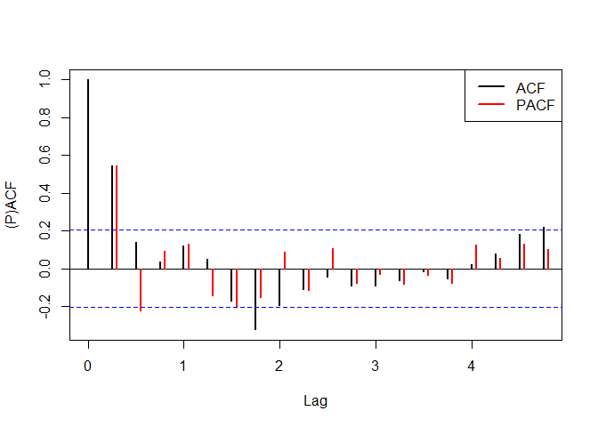

```r
acf(dat$train$RTSC, ylab="(P)ACF", main="", lwd=2)
tmp <- pacf(dat$train$RTSC, plot=F)
points(tmp$lag+0.2/4, tmp$acf, col="red", type = "h", lwd=2)
legend("topright", legend=c("ACF","PACF"), col = c("black","red"), lty=c(1,1), lwd=2)
```

```r
pmax <- 5
qmax <- 7
kmax <- 10
```

## Odhad najlepšieho ARMA modelu podľa BIC kritéria

```r
pqBIC <- c()
for(p in 0:pmax) {
  for(q in 0:qmax) {
    if(p==0 & q==0) next    # ARMA(0,0) neodhadne
    fit <- arima(dat$train$RTSC, order=c(p,0,q),method="ML")
    pqBIC <- rbind(pqBIC, c(p,q,BIC(fit)))
  }
}
# zoradenie odhadov podľa BIC
pqBIC <- pqBIC[order(pqBIC[,3]),]
head(pqBIC)
```

```
##      [,1] [,2]     [,3]
## [1,]    1    2 753.1054
## [2,]    0    2 754.8733
## [3,]    0    1 755.6931
## [4,]    2    0 756.2287
## [5,]    1    1 756.4665
## [6,]    1    0 758.0006
```

vytvoríme 5 najlepších modelov a vykreslíme ich spolu s reziduálnou zložkou

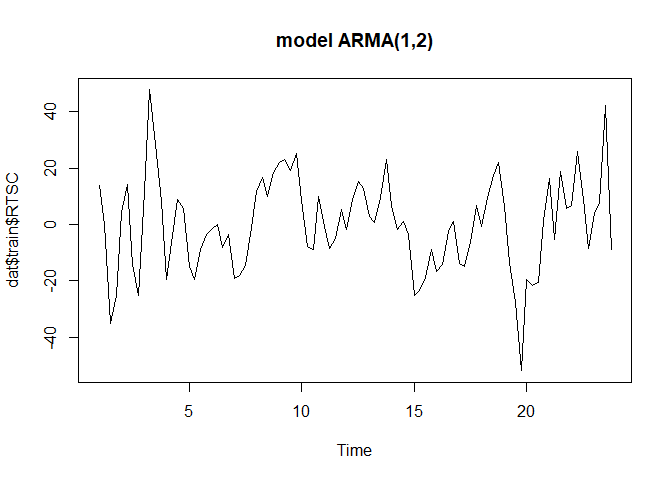

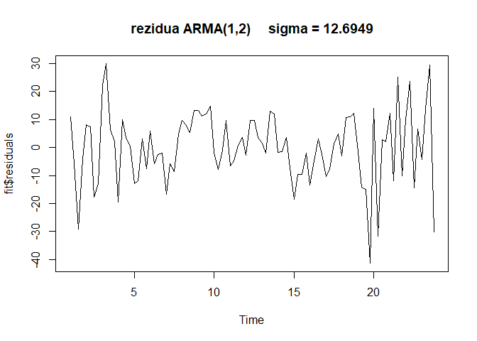

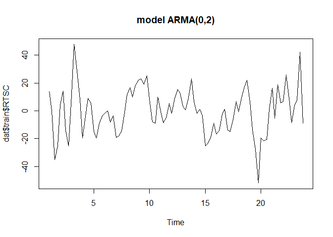

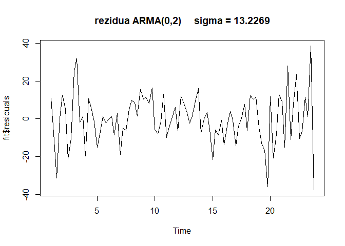

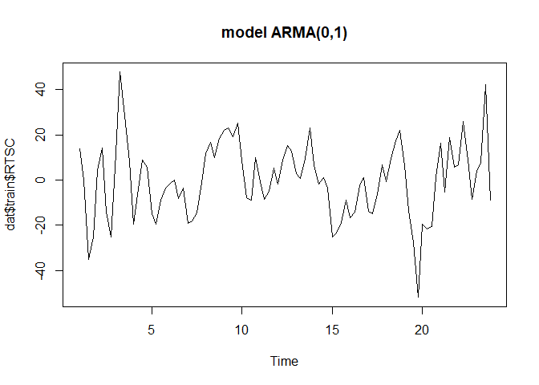

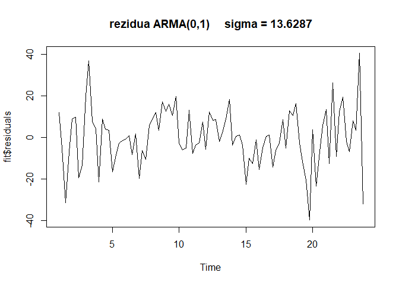

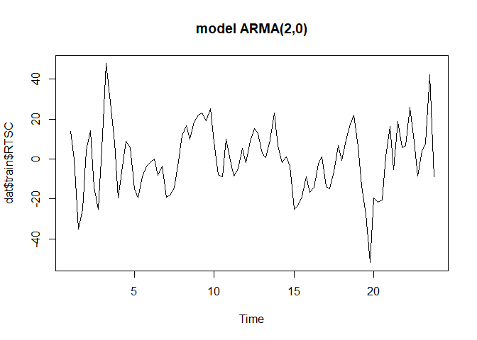

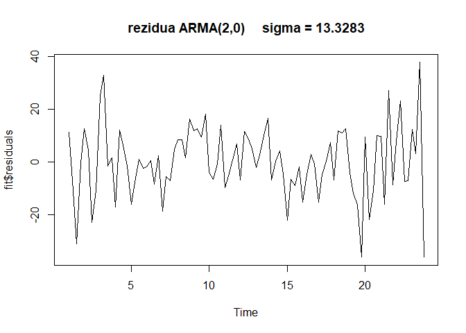

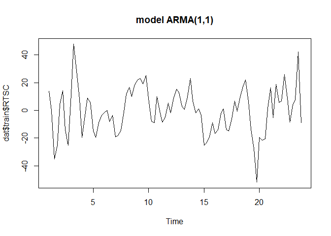

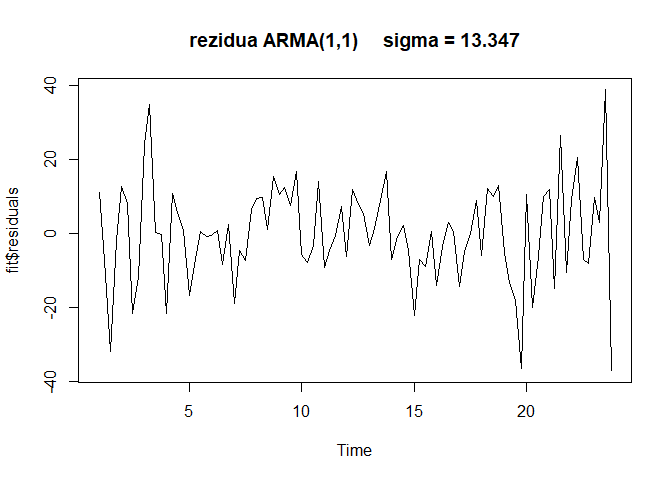

```r
model$Rarma <- list()
for(i in 1:5) {
  p <- pqBIC[i,1]
  q <- pqBIC[i,2]
  id <- paste0("ARMA(", p, ",", q, ")")
  fit <- model$Rarma[[id]] <- arima(dat$train$RTSC, order=c(p,0,q))
  # je potrebne použiť dvojité zátvorky [[]]
  plot(dat$train$RTSC, main=paste("model", id) )   # zobraz data
  lines(fitted(fit), col="blue")  # a na nich modelové hodnoty
  plot(fit$residuals, main=paste("rezidua", id, "    sigma =", round(sqrt(fit$sigma2),4)))
  # vykresli rezíduá
}
```

# Zostrojenie celkového modelu

zobrazenie možného finálneho modelu spolu s pôvodnými dátami

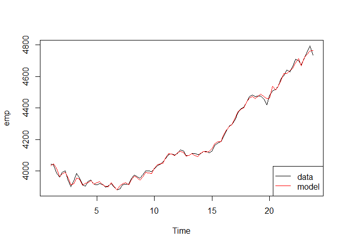

```r
with(dat$train, {
  fit <- TSC + (RTSC - model$Rarma$`ARMA(1,2)`$residuals)
  emp <- 'tsp<-'(ts(emp), tsp(fit))
  plot(emp, type="l")
  lines(fit, col="red")
  legend("bottomright", legend=c("data","model"), lty=1, pch=c(NA,NA), col=c("black","red"))
})
```

# Diagnostika odhadnutého modelu

## test stacionarity modelu

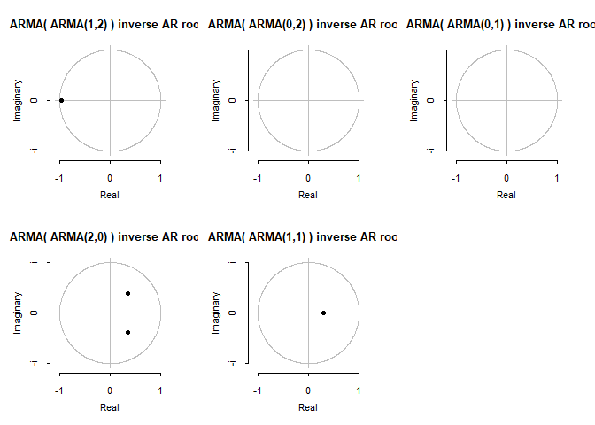

```r
old <- par(mfrow=c(2,3))
for(i in names(model$Rarma)) {
  forecast:::plot.Arima(model$Rarma[[i]], type='ar', main=paste("ARMA(",i,") inverse AR roots"))
}
par(old)
```

## Test nekorelovanosti reziduí

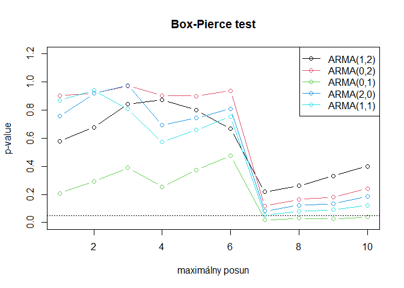

```r
sapply(1:kmax, function(x) Box.test(model$Rarma[[1]]$residuals, lag=x)$p.value) %>%
  plot(type="b", ylim=c(0,1.2), xlab="maximálny posun", ylab="p-value", main="Box-Pierce test")
abline(h=0.05, lty="dotted")

for(i in 2:length(model$Rarma)) {
  sapply(1:kmax, function(x) Box.test(model$Rarma[[i]]$residuals, lag=x)$p.value) %>%
    lines(type="b", col=i)
}
legend("topright", legend=paste0(names(model$Rarma)), col=1:5, pch=1, lty=1, bg = "white")
```